# Week 12

Suraj Radhakrishnan

February 17, 2019

# K-means Cluster Analysis

In this section we will understand the use of clustering techniques to find subgroups of observations within a dataset. When we cluster observations, we want observations in the same group to be similar and observations in different groups to be dissimilar.

For our clustering analysis, we will use the “birth.death.rates.1966” dataset. A table with birth and death rates per 1000 persons for selected countries.

Let us load the data in R and make sure there are no missing values; Even if there are any missing values, we make sure to omit them.

```r
data("birth.death.rates.1966")
str(birth.death.rates.1966)
```

```
## 'data.frame':    70 obs. of  3 variables:
##  $ country: chr  "Algeria" "Congo" "Egypt" "Ghana" ...
##  $ birth  : num  36.4 37.3 42.1 55.8 56.1 41.8 46.1 41.7 41.4 35.8 ...
##  $ death  : num  14.6 8 15.3 25.6 33.1 15.8 18.7 10.1 19.7 8.5 ...
```

```r
C.Data <- birth.death.rates.1966
C.Data <- na.omit(C.Data)
head(C.Data)
```

```
##       country birth death
## 1     Algeria  36.4  14.6
## 2       Congo  37.3   8.0
## 3       Egypt  42.1  15.3
## 4       Ghana  55.8  25.6
## 5 Ivory Coast  56.1  33.1
## 6    Malagasy  41.8  15.8
```

Let us now scale the numeric variables in the dataset.

```r
C.Data$birth <- scale(C.Data$birth)
C.Data$death <- scale(C.Data$death)
head(C.Data)
```

```
##       country     birth      death
## 1     Algeria 0.6258084  0.8946104
## 2       Congo 0.7028573 -0.4923359
## 3       Egypt 1.1137848  1.0417108
## 4       Ghana 2.2866405  3.2061876
## 5 Ivory Coast 2.3123235  4.7822630
## 6    Malagasy 1.0881019  1.1467825
```

## Clustering distance measures

In compute the distance matrix in R, we use the get_dist and fviz_dist functions. These functions are contained in the factoextra R package.

Using get_dist, we first compute a distance matrix between the rows of the data matrix. By default, the distance measure used is Euclidean distance. fviz_dist is then used for visualizing a distance matrix. Let us see how the code works in R.

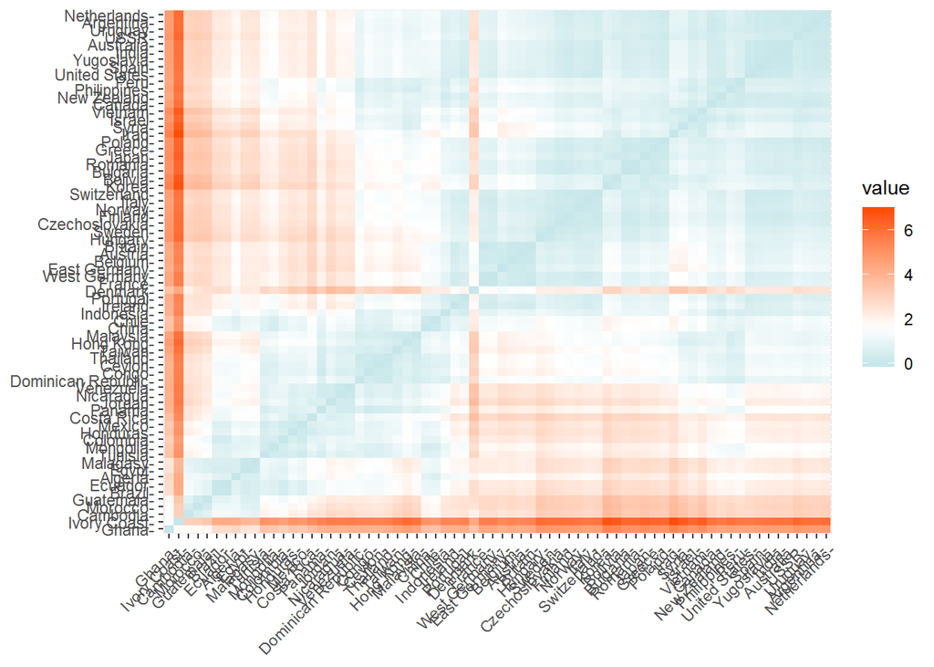

```r
rownames(C.Data) <- C.Data$country
C.Data$country <- NULL
distance <- get_dist(C.Data)
fviz_dist(distance, gradient = list(low = "#00AFBB", mid = "white", high = "#FC4E07"))
```

## K-means clustering in R

Let us start with 2 clusters. We also use the nstart function to attempt multiple configurations. This will help identify the optimal configuration.

We run the following R code and analyze the results:

```r
cluster2 <- kmeans(C.Data, centers = 2, nstart = 25)
str(cluster2)
```

```
## List of 9
##  $ cluster     : Named int [1:70] 1 1 1 1 1 1 1 1 1 2 ...
##   ..- attr(*, "names")= chr [1:70] "Algeria" "Congo" "Egypt" "Ghana" ...
##  $ centers     : num [1:2, 1:2] 1.232 -0.603 0.639 -0.313
##   ..- attr(*, "dimnames")=List of 2
##   .. ..$ : chr [1:2] "1" "2"
##   .. ..$ : chr [1:2] "birth" "death"
##  $ totss       : num 138
##  $ withinss    : num [1:2] 44.8 27.2
##  $ tot.withinss: num 72
##  $ betweenss   : num 66
##  $ size        : int [1:2] 23 47
##  $ iter        : int 1
##  $ ifault      : int 0
##  - attr(*, "class")= chr "kmeans"
```

```r
cluster2
```

```
## K-means clustering with 2 clusters of sizes 23, 47
##
## Cluster means:
##        birth      death
## 1  1.2321498  0.6387837
## 2 -0.6029669 -0.3125963
##
## Clustering vector:
##            Algeria              Congo              Egypt
##                  1                  1                  1
##              Ghana        Ivory Coast           Malagasy
##                  1                  1                  1
##            Morocco            Tunisia           Cambodia
##                  1                  1                  1
##             Ceylon              China             Taiwan
##                  2                  1                  2
##          Hong Kong              India          Indonesia
##                  2                  2                  2
##               Iraq             Israel              Japan
##                  2                  2                  2
##             Jordan              Korea           Malaysia
##                  1                  2                  2
##           Mongolia        Philippines              Syria
##                  1                  2                  2
##           Thailand            Vietnam             Canada
##                  2                  2                  2
##         Costa Rica Dominican Republic          Guatemala
##                  1                  2                  1
##           Honduras             Mexico          Nicaragua
##                  1                  1                  1
##             Panama      United States          Argentina
##                  1                  2                  2
##            Bolivia             Brazil              Chile
##                  2                  1                  1
##           Colombia            Ecuador               Peru
##                  1                  1                  2
##            Uruguay          Venezuela            Austria
##                  2                  1                  2
##            Belgium            Britain           Bulgaria
##                  2                  2                  2
```

[output cut: 11 more lines]

```
##                  2                  2                  2
##               USSR         Yugoslavia          Australia
##                  2                  2                  2
##        New Zealand
##                  2
##
## Within cluster sum of squares by cluster:
## [1] 44.82298 27.19313
##  (between_SS / total_SS =  47.8 %)
##
## Available components:
##
## [1] "cluster"      "centers"      "totss"        "withinss"
## [5] "tot.withinss" "betweenss"    "size"         "iter"
## [9] "ifault"
```

The results can also be viewed using the fviz_cluster function which will provide an effective visual illustration of the results of our K means clustering method.

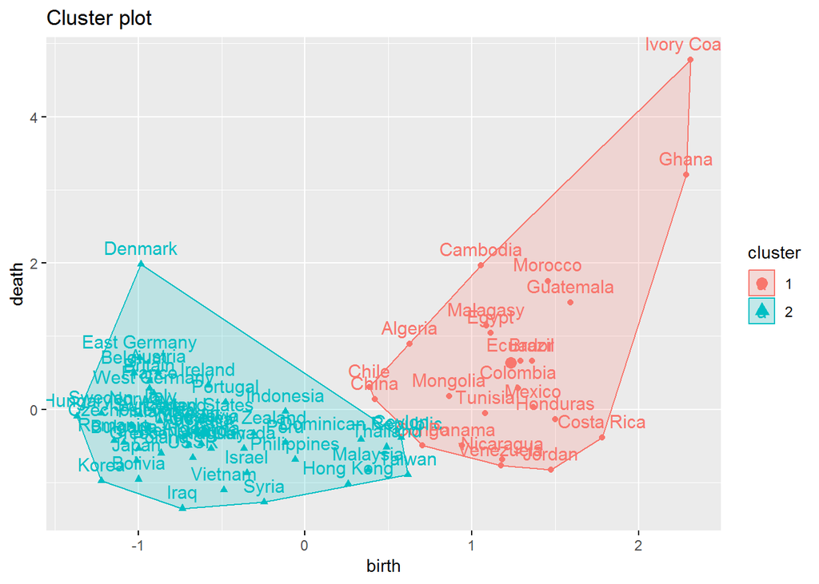

```r
fviz_cluster(cluster2, data = C.Data)
```

```r
cluster3 <- kmeans(C.Data, centers = 3, nstart = 25)
cluster4 <- kmeans(C.Data, centers = 4, nstart = 25)
cluster5 <- kmeans(C.Data, centers = 5, nstart = 25)
cluster6 <- kmeans(C.Data, centers = 6, nstart = 25)
cluster7 <- kmeans(C.Data, centers = 7, nstart = 25)
```

Let us now plot to compare the variation in the results.

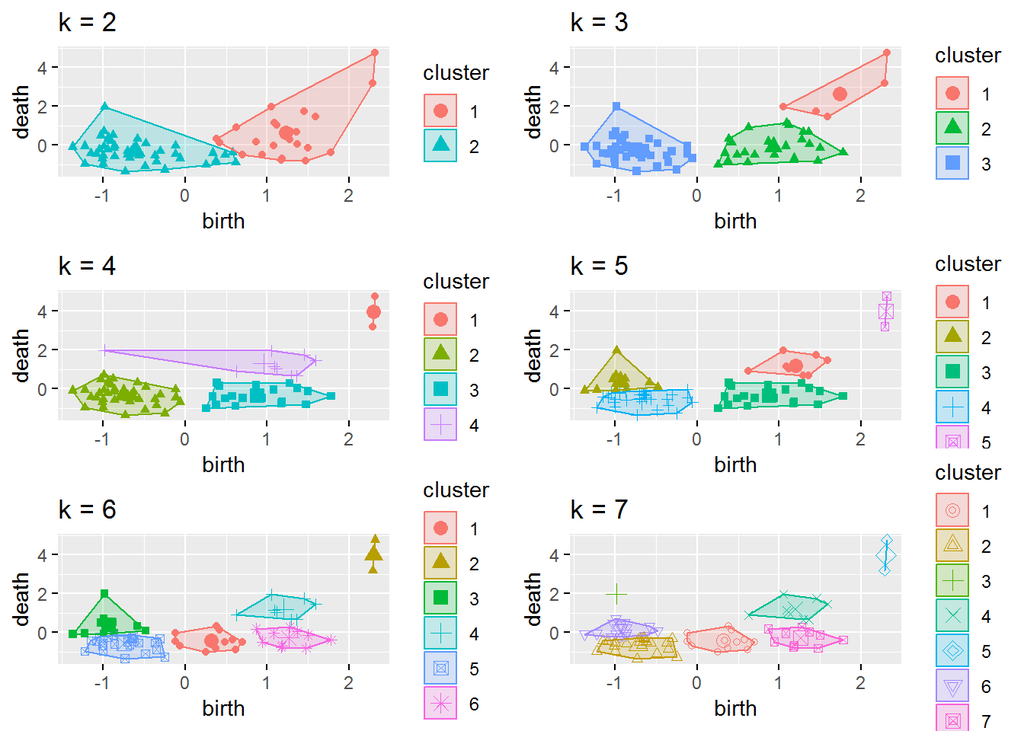

```r
p1 <- fviz_cluster(cluster2, geom = "point", data = C.Data) + ggtitle("k = 2")
p2 <- fviz_cluster(cluster3, geom = "point",  data = C.Data) + ggtitle("k = 3")
p3 <- fviz_cluster(cluster4, geom = "point",  data = C.Data) + ggtitle("k = 4")
p4 <- fviz_cluster(cluster5, geom = "point",  data = C.Data) + ggtitle("k = 5")
p5 <- fviz_cluster(cluster6, geom = "point",  data = C.Data) + ggtitle("k = 6")
p6 <- fviz_cluster(cluster7, geom = "point",  data = C.Data) + ggtitle("k = 7")
grid.arrange(p1, p2, p3, p4,p5,p6, nrow = 3)
```

## Determining the optimal number of clusters

While the above graphs help us to compare the variation in the clustering results for different numbers of clusters, it does not help us identify the optimal number of clusters. There are several methods to do this.

### Elbow method

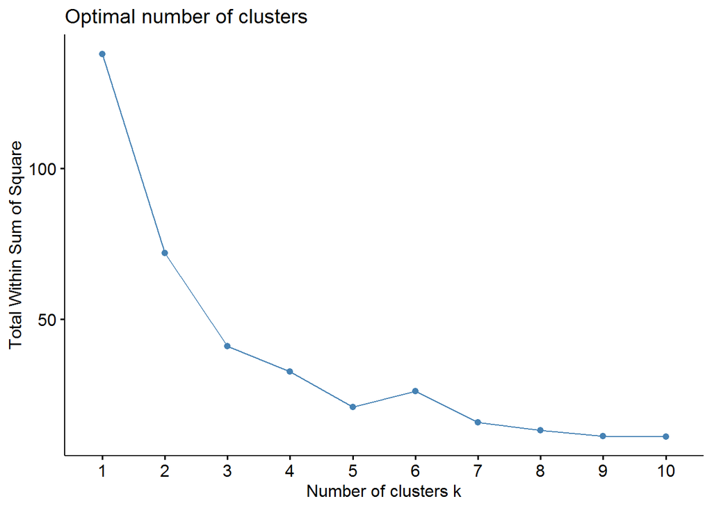

```r
set.seed(123)

fviz_nbclust(C.Data, kmeans, method = "wss")
```

This method indicates that the optimal number of clusters is 3 as evidenced by the bend in the elbow.

### Average Silhouette method

The same can also be accomplished using the average silhouette method:

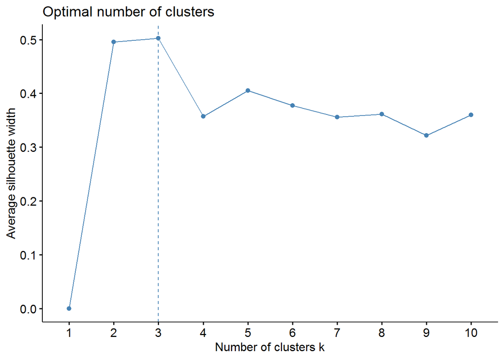

```r
fviz_nbclust(C.Data, kmeans, method = "silhouette")
```

This method also indicates that the optimal number of clusters is 3 similar to the elbow method.

### Gap statistic method

We can compute this using the clusGap function which provides the gap statistic and a standard error for the output.

```r
# compute gap statistic
set.seed(123)
gap_stat <- clusGap(C.Data, FUN = kmeans, nstart = 25,
                    K.max = 10, B = 50)
# Print the result
print(gap_stat, method = "firstmax")
```

```
## Clustering Gap statistic ["clusGap"] from call:
## clusGap(x = C.Data, FUNcluster = kmeans, K.max = 10, B = 50,     nstart = 25)
## B=50 simulated reference sets, k = 1..10; spaceH0="scaledPCA"
##  --> Number of clusters (method 'firstmax'): 1
##           logW   E.logW       gap     SE.sim
##  [1,] 3.342324 3.852859 0.5105351 0.04203253
##  [2,] 2.968810 3.428969 0.4601597 0.03841341
##  [3,] 2.744733 3.232343 0.4876100 0.03580874
##  [4,] 2.590037 3.060697 0.4706601 0.03365473
##  [5,] 2.427004 2.910477 0.4834727 0.03468266
##  [6,] 2.315812 2.783687 0.4678751 0.03060329
##  [7,] 2.237548 2.672376 0.4348283 0.03086387
##  [8,] 2.143259 2.574858 0.4315985 0.03319521
##  [9,] 2.079546 2.485666 0.4061197 0.03732248
## [10,] 1.960423 2.404849 0.4444259 0.03832939
```

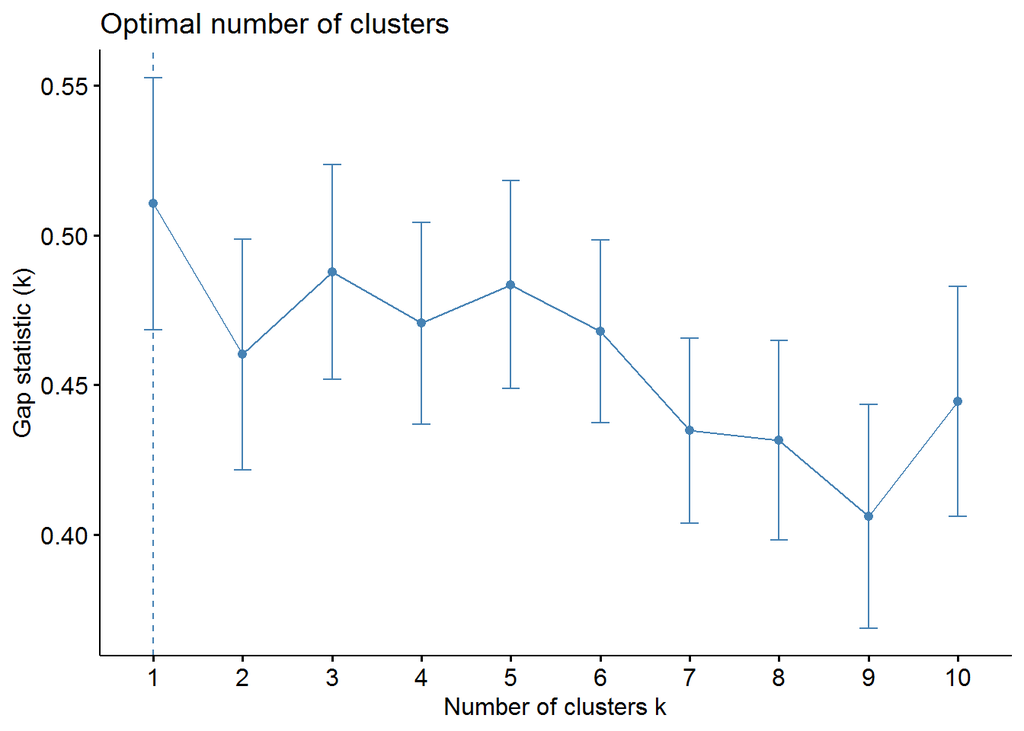

```r
fviz_gap_stat(gap_stat)
```

This method suggests that 1 cluster will be optimal followed by 3 clusters.

## Final cluster analysis

As most of the methods suggeested 3 as the most oprimal number of clusters, we perform the final analysis:

```r
set.seed(123)
final <- kmeans(C.Data, 3, nstart = 25)
print(final)
```

```
## K-means clustering with 3 clusters of sizes 24, 41, 5
##
## Cluster means:
##        birth      death
## 1  0.9286534 -0.1053219
## 2 -0.7558519 -0.2596406
## 3  1.7404493  2.6345976
##
## Clustering vector:
##            Algeria              Congo              Egypt
##                  1                  1                  1
##              Ghana        Ivory Coast           Malagasy
##                  3                  3                  1
##            Morocco            Tunisia           Cambodia
##                  3                  1                  3
##             Ceylon              China             Taiwan
##                  1                  1                  1
##          Hong Kong              India          Indonesia
##                  1                  2                  2
##               Iraq             Israel              Japan
##                  2                  2                  2
##             Jordan              Korea           Malaysia
##                  1                  2                  1
##           Mongolia        Philippines              Syria
##                  1                  2                  2
##           Thailand            Vietnam             Canada
##                  1                  2                  2
##         Costa Rica Dominican Republic          Guatemala
##                  1                  1                  3
##           Honduras             Mexico          Nicaragua
##                  1                  1                  1
##             Panama      United States          Argentina
##                  1                  2                  2
##            Bolivia             Brazil              Chile
##                  2                  1                  1
##           Colombia            Ecuador               Peru
##                  1                  1                  2
##            Uruguay          Venezuela            Austria
##                  2                  1                  2
##            Belgium            Britain           Bulgaria
```

[output cut: 12 more lines]

```
##                  2                  2                  2
##               USSR         Yugoslavia          Australia
##                  2                  2                  2
##        New Zealand
##                  2
##
## Within cluster sum of squares by cluster:
## [1] 13.948085 18.317514  8.731563
##  (between_SS / total_SS =  70.3 %)
##
## Available components:
##
## [1] "cluster"      "centers"      "totss"        "withinss"
## [5] "tot.withinss" "betweenss"    "size"         "iter"
## [9] "ifault"
```

We visualize the results using fviz_cluster function.

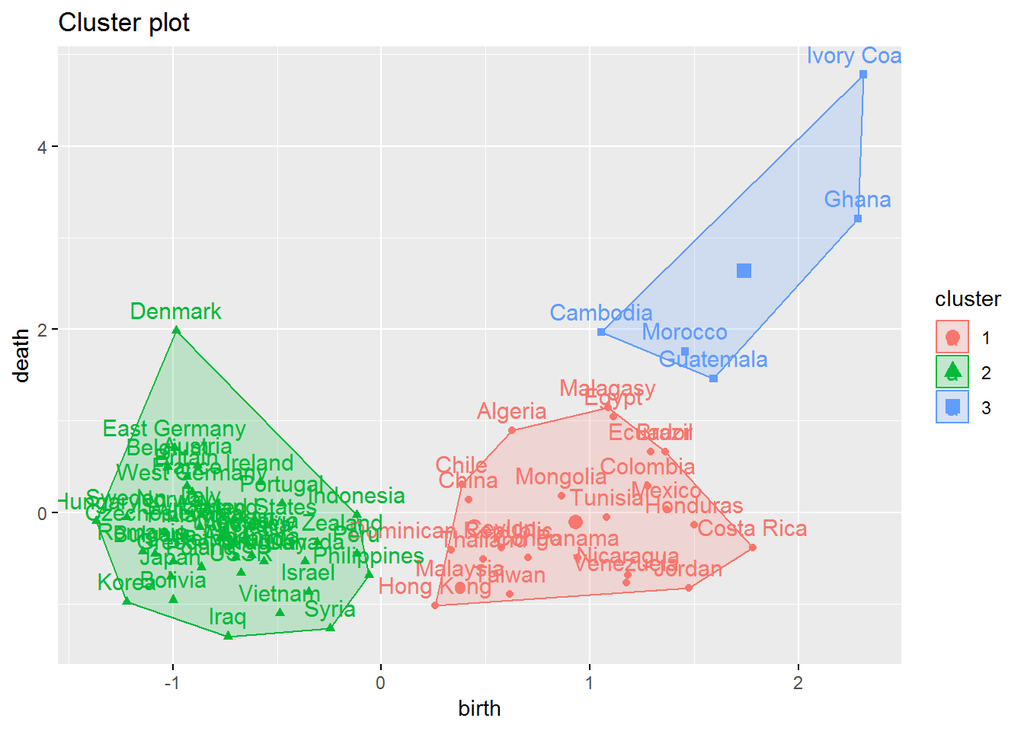